# Generalized Linear Mixed Models

An Introduction

Joshua F. Wiley

2019-04-15

```r
options(digits = 2)

library(data.table)
library(lme4)
library(ggplot2)
library(visreg)

## read in the dataset
d <- readRDS("aces_daily_sim_processed.RDS")
```

# The Generalized Linear Model

We have already seen the linear model

For example, t-tests, Analysis of Variance, Pearson correlations, and Linear Regression are all cases of linear models

- $y = b_0 + b_1 * x_1 + ... + b_k * x_k + e$

The linear model is a *special case* of the **generalized linear model** or **GLM**

The GLM extends the linear model to different types of outcomes

The probit model is also used for binary variables. Unlike normally distributed outcomes, count outcomes take on integer values (0, 1, 2, *not* 0.5 or 1.5) and counts cannot be negative.

- binary 0/1 variables (logistic regression)
- count variables (poisson regression)
- Many other types of variables

This lecture focuses on *logistic mixed effects models* for binary variables

## Notation and some Theory

We already learned about linear regression

- $y = b_0 + b_1 * x_1 + ... + b_k * x_k + e$

First, we simplify the notation a bit

- $\eta = b_0 + b_1 * x_1 + ... + b_k * x_k$
- $y = \eta + e$

For linear regression, we assumed a *normal* distribution

The normal distribution has two parameters

Note the mean sometimes called the *location* because it controls the location of the center of the distribution and the standard deviation is sometimes called the *scale* because it controls the scale or spread of the distribution

- mean ($\mu$)
- standard deviation ($\sigma$)
- Normal distribution can be written: $N(\mu, \sigma)$

In linear regression, what we are really assuming is that

- $y \sim N(\eta, \sigma)$

Which is read, “Y is distributed as a normal distribution with mean equal to $\eta$ and standard deviation $\sigma$”.

$\sigma$ is typically estimated as standard deviation of the residuals, $e$.

Any GLM has to be a linear model at some level, that is, this is always true:

- $\eta = b_0 + b_1 * x_1 + ... + b_k * x_k$

The GLM generalizes linear regression by defining a *function* that links or transforms $\eta$ to the outcome

The link function is always called $g()$. Likewise an inverse link function exists that simple “undoes” whatever the link function did. This is called $g()^{-1}$.

In normal linear regression, the link function and inverse link function are just the identity function, that is *there is no transformation*

For many other types of regression, including *logistic regression* the link and inverse link functions do some transformation.

In terms of formulae, we define the expected value of $y$, its mean, as $\mu$

- $E(y) = \mu =$ mean of $y$

Then

- $\eta = g(\mu)$
- $\mu = g^{-1}(\eta)$

For normal linear regression because the link and inverse link functions are the identity function this works out to be

- $\eta = g(\mu) = \mu$
- $\mu = g^{-1}(\eta) = \eta$

The powerful concept of the GLM is that by using link functions, the linear model

- $\eta = b_0 + b_1 * x_1 + ... + b_k * x_k$

always stays the same whether the outcome is continuous and normally distributed or binary and not normally distributed or count or any other type of variable and assumed distribution

This means in some sense, all GLMs are interpretted like linear regression, so in a way you already know logistic regression!

Next, we explore the link functions for logistic regression that make the transformation from a linear scale to a binary scale.

## Logistic Regression

Logistic regression is regression when the outcome only takes on two values: 0 or 1.

Logistic regression is useful for many questions

- What predicts whether someone will have major depression or not?
- Does one treatment have a higher probability of patients *remitting* from major depression than another treatment?

Linear regression will not work for binary outcomes for two reasons:

- First, when an outcome can only be 0 or 1, a straight line is a very bad fit
  - straight lines could predict a value of 1.4 or 2 or -0.3 when those values are not possible
- Second, there is no way that a binary variable or its residuals will follow a normal distribution: the normality assumption would be violated

The GLM solves each of these problems separately

- Link functions transform the linear predicted value $\eta$ so that it never goes below 0 and never goes about 1
- Rather than assume a normal distribution, the GLM uses a new distribution, the Bernoulli distribution
  - Whereas the Normal distribution had two parameters, mean and standard deviation, the Bernoulli distribution only has one: the probability that an event will occur

For logistic regression, the link function is defined as:

- $\eta = g(\mu) = ln\left(\frac{\mu}{1 - \mu}\right)$

That is called the *logit* function.

Here $\mu$ is the probability that the outcome will be 1. Probabilities range from 0 to 1: an outcome cannot happen less than never (probability of 0) or more than always (probability of 1).

Graphing $\mu$ against $\mu$ we get

Figure 1. Probabilities against Probabilities

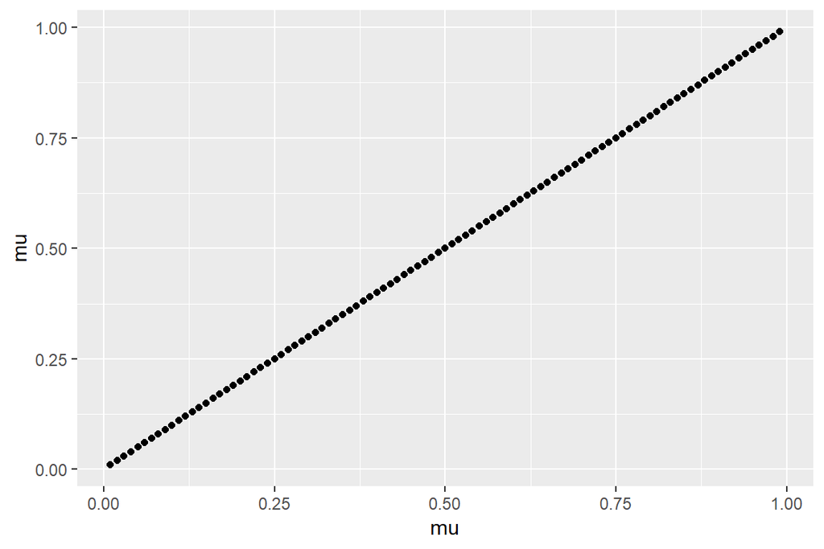

```r
tmp <- data.frame(mu = seq(from = .01, to = .99, by = .01))
ggplot(tmp, aes(mu, mu)) +
  geom_point()
```

The first part of the *logit* function:

- $\frac{\mu}{1 - \mu}$

unbounds $\mu$ on the right side, so that as it goes to 1, transformed, it goes to infinity, shown graphically below

Figure 2. Probabilities against right unbounded probabilities

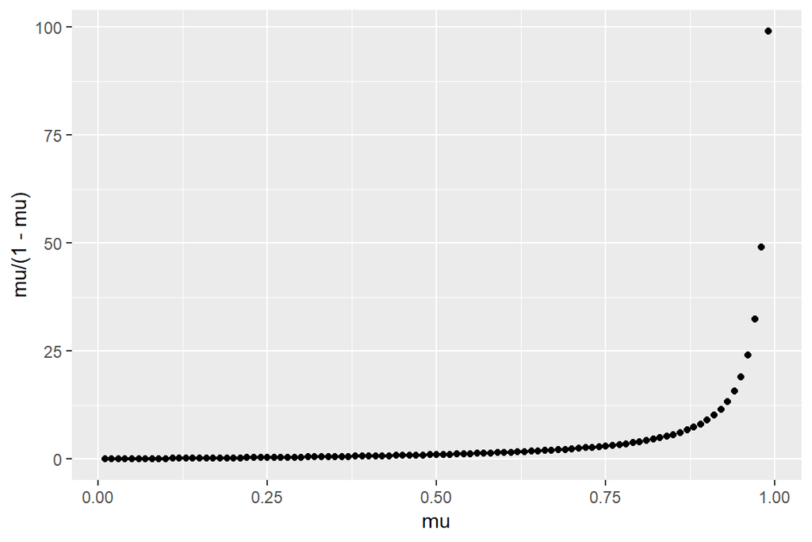

```r
ggplot(tmp, aes(mu, mu/(1 - mu))) +
  geom_point()
```

The next part, the natural logarithm, unbounds it on the left side because the log of 0 is negative infinity

- $ln\left(\frac{\mu}{1 - \mu}\right)$

Combined, the graph below shows the raw $\mu$ values against the transformed values.

Figure 3. Probabilities against unbounded probabilities (logit scale)

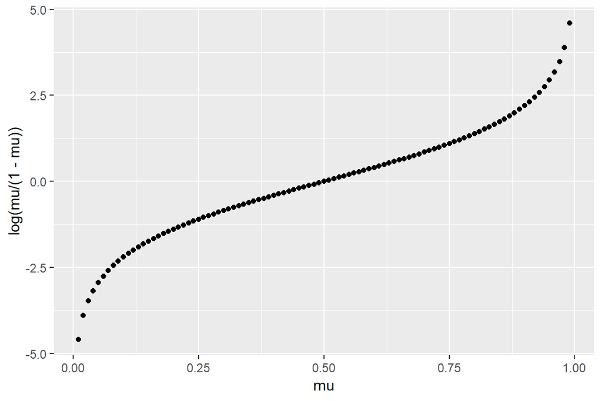

```r
ggplot(tmp, aes(mu, log(mu/(1 - mu)))) +
  geom_point()
```

In this way, the link function for logistic regression takes the probability of the event occuring, which can only fall between 0 and 1, and transforms it to fall between negative infinity and positive infinity

Now we have a continuous and unbounded outcome we can apply a linear model to!

To go from predictions on the linear model back to the probability scale, we use the inverse link function:

- $\mu = g^{-1}(\eta) = \frac{1}{1 + e^{-\eta}}$

That is, suppose we had the linear predicted values, $\eta$ shown below graphically

Figure 4. Linear predictor against linear predictor

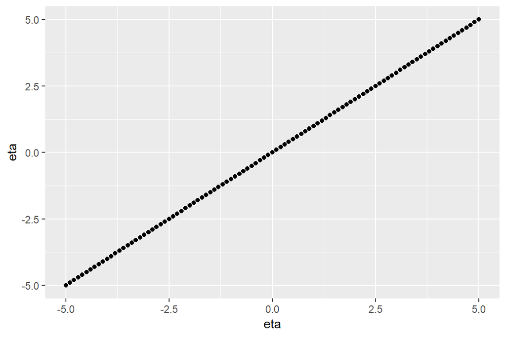

```r
tmp2 <- data.frame(eta = seq(from = -5, to = 5, by = .1))
ggplot(tmp2, aes(eta, eta)) +
  geom_point()
```

Using the inverse link function, we transform them to again fall between 0 and 1, like probabilities.

Figure 5. Linear predictor (logit scale) against probabilities

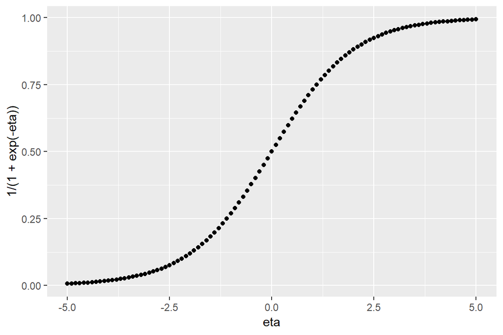

```r
ggplot(tmp2, aes(eta, 1/(1 + exp(-eta)))) +
  geom_point()
```

## Logistic Regression Assumptions

Much like a normal distribution was assumed for normal linear regression, for logistic regression a Bernoulli distribution is assumed.

- $y \sim Bern(\mu)$

The Bernoulli only has the one parameter, the probability of the event occuring.

In logistic regression the outcome is either 0 or 1, so outliers on the outcome are not a concern

Outliers on predictors may still be a concern

One problem that sometimes arises is known as separation, this occurs when some predictor perfectly predicts the outcome or separates the outcome, most often when the outcome is rare or the sample size is small.

- In a sample of 60 people where only 10 have major depression, if 80% of the sample also have PTSD, it may happen that all cases of major depression occurred in people with PTSD, so the percentage of depression in those without PTSD is exactly 0%, which is separation.
- The usual solution is to remove predictors or collapse groups in these cases

Logistic regression still requires that the errors be independent (i.e., individuals are independent, not dependent or repeated measures). Generalized linear mixed models (GLMMs) and specifically logistic mixed effects models relax the indepedence assumption.

Logistic regression also assumes that on the linke scale (logit scale) there is a linear relationship.

Finally, logistic regression generally requires a large sample size. There are no degrees of freedom, requires large enough sample that parameters are distributed about normally (central limit theorem).

## Simple Logistic Regression (Example 1)

First, let’s test whether women or men in the study are more likely to be born in or outside of Australia. To begin with and avoid a repeated measures dataset, we will make a dataset without repeated data.

Download the script to run all the examples in lecture here: https://jwiley.github.io/MonashHonoursStatistics/GLMM_slides.rmd Note that this is a new kind of file, but you can also open it in RStudio. It combines text and has `R` code in “chunks” marked by three back ticks and is called an `R` markdown file. `R` markdown is a very flexible way to write text or notes in between pieces of `R` code. The whole document can be “processed” or rendered by `R` and the result has both the text, the code and the output, which is a great way to do your analyses keeping enough records and notes of why you are doing things or how to interpret them. To see more possibilities, go to: https://rmarkdown.rstudio.com/

```r
## create a new dataset with just 6 variables
## BSTRESS and BPosAff are average stress and PosAff
wd <- d[, .(UserID, BornAUS, Female,
            Age, BSTRESS, BPosAff)]

## omit any rows (observations) that are missing
## any variable
wd <- na.omit(wd)

## exclude any rows with duplicated IDs
## this results in just one row per ID
wd <- wd[!duplicated(UserID)]

dim(wd)
```

```
## [1] 190   6
```

There are 190 people in this little dataset. Below we ask `R` for frequency tables

```r
table(wd$Female)
```

```
##
##   0   1
##  75 115
```

```r
table(wd$BornAUS)
```

```
##
##   0   1
## 125  65
```

To run the logistic regression, we need four pieces

- the `glm()` function for the logistic regression model
- A formula indicating our model of the form:
  - dependent variable ~ predictor
- The name of the assumed distribution, `binomial()`
- The name of the dataset, “wd”

```r
m1 <- glm(BornAUS ~ Female,
          family = binomial(),
          data = wd)
summary(m1)
```

```
##
## Call:
## glm(formula = BornAUS ~ Female, family = binomial(), data = wd)
##
## Deviance Residuals:
##    Min      1Q  Median      3Q     Max
## -1.011  -1.011  -0.764   1.354   1.657
##
## Coefficients:
##             Estimate Std. Error z value Pr(>|z|)
## (Intercept)   -1.081      0.265   -4.07  4.7e-05 ***
## Female         0.675      0.327    2.07    0.039 *
## ---
## Signif. codes:  0 '***' 0.001 '**' 0.01 '*' 0.05 '.' 0.1 ' ' 1
##
## (Dispersion parameter for binomial family taken to be 1)
##
##     Null deviance: 244.12  on 189  degrees of freedom
## Residual deviance: 239.69  on 188  degrees of freedom
## AIC: 243.7
##
## Number of Fisher Scoring iterations: 4
```

The output shows several things:

- The deviance residuals
- A coefficient table, like linear regression
  - Estimate: familiar regression coefficients on linear scale
  - Std. Error: standard error for the regression coefficients
  - z value: takes the place of the t statistic in normal linear regression, this is essentially a z-test
  - Pr(>|z|): the p-value, based on the Z value
- The **residual deviance** degrees of freedom: sample size - number parameters (here two: one for intercept, one for Female slope)
- The Akaike Information Criterion (AIC) which can be used to compare different models.

With a simple model, we can easily convert from the logit scale to the probability scale

Men are the reference group, captured by the intercept

- $\frac{1}{1 + e^{- (-1.08)}} = 0.25$
  - Men have a 0.25 probability of being born in Australia

The coefficient for women, indicates that women have 0.68 higher log odds (the logit scale) of being born in Australia than do men

To calculate the probability that women will be born in Australia:

- $\frac{1}{1 + e^{- (-1.08 + 0.68)}} = 0.4$
  - Women have a 0.4 probability of being born in Australia

Rather than interpret coefficients on the log odds (logit) scale, people commonly exponentiate the coefficients so they are on the odds scale.

- Women have $e^{0.68} = 1.96$ times the odds of being born in Australia as do men
- This is called the odds ratio (OR)

An example summary of this analysis is: “Women were more likely to be born in Australia than men, (OR = 1.96, p = .039).”

Another way of saying the same thing: “Women had 1.96 times the odds of being born in Australia as women (p = .039).”

## Simple Logistic Regression (Example 2)

Next we examine a continuous predictor, average level of positive affect as a predictor of whether participants were born in Australia.

The figure below shows the distribution of average positive affect, “BPosAff”

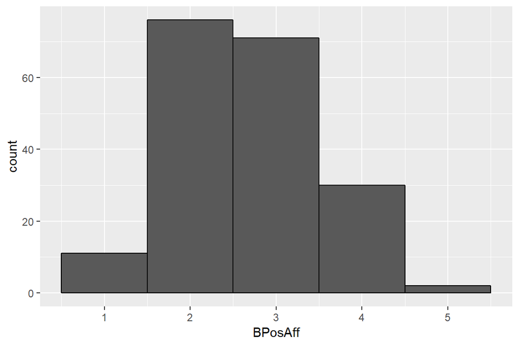

```r
ggplot(wd, aes(BPosAff)) +
  geom_histogram(binwidth=1, colour = "black")
```

The analysis in `R` is very similar to the previous example:

```r
m2 <- glm(BornAUS ~ BPosAff,
          family = binomial(),
          data = wd)
summary(m2)
```

```
##
## Call:
## glm(formula = BornAUS ~ BPosAff, family = binomial(), data = wd)
##
## Deviance Residuals:
##    Min      1Q  Median      3Q     Max
## -1.232  -0.924  -0.799   1.347   1.753
##
## Coefficients:
##             Estimate Std. Error z value Pr(>|z|)
## (Intercept)   -1.756      0.556   -3.16   0.0016 **
## BPosAff        0.405      0.194    2.09   0.0366 *
## ---
## Signif. codes:  0 '***' 0.001 '**' 0.01 '*' 0.05 '.' 0.1 ' ' 1
##
## (Dispersion parameter for binomial family taken to be 1)
##
##     Null deviance: 244.12  on 189  degrees of freedom
## Residual deviance: 239.65  on 188  degrees of freedom
## AIC: 243.7
##
## Number of Fisher Scoring iterations: 4
```

- The coefficient for average positive afffect indicates that for every one unit change in average PosAff, people have 0.41 higher log odds of being born in Australia
- In odds ratios:
  - For each additional unit higher average positive affect, participants have 1.5 times the odds of being born in Australia (p = .037).
- One challenge with the odds ratio metric is that it is multiplicative
  - If the baseline odds are 2, then 1.2 times the odds would be 2.4 (an absolute difference of 0.4)
  - If the baseline odds are 4, then 1.2 times the odds would be 4.8 (an absolute difference of 0.8)
- Important to keep this interpretation in mind, odds ratios do not directly indicate the probability of the event occuring, just how many times higher the odds

We can calculate the specific probability of being born in Australia as we did for sex

Probability of being born in Australia for participants with 0 average positive affect

- $\frac{1}{1 + e^{- (-1.76)}} = 0.15$
  - Participants with 0 average positive affect have a 0.15 probability of being born in Australia

Probability of being born in Australia for participants with a 4 average positive affect

- First calculate the log odds
  - $-1.76 + 0.41 * 4 = -0.14$
- Then convert the log odds to probabilities
- $\frac{1}{1 + e^{- (-0.14)}} = 0.47$
  - Participants with a 4 average positive affect have a 0.47 probability of being born in Australia

## Multiple Logistic Regression (Example 3)

Include both sex and average positive affect as predictors.

```r
m3 <- glm(BornAUS ~ Female + BPosAff,
          family = binomial(),
          data = wd)
summary(m3)
```

```
##
## Call:
## glm(formula = BornAUS ~ Female + BPosAff, family = binomial(),
##     data = wd)
##
## Deviance Residuals:
##    Min      1Q  Median      3Q     Max
## -1.393  -0.942  -0.739   1.279   1.945
##
## Coefficients:
##             Estimate Std. Error z value Pr(>|z|)
## (Intercept)   -2.358      0.640   -3.68  0.00023 ***
## Female         0.749      0.334    2.24  0.02512 *
## BPosAff        0.452      0.200    2.26  0.02368 *
## ---
## Signif. codes:  0 '***' 0.001 '**' 0.01 '*' 0.05 '.' 0.1 ' ' 1
##
## (Dispersion parameter for binomial family taken to be 1)
##
##     Null deviance: 244.12  on 189  degrees of freedom
## Residual deviance: 234.41  on 187  degrees of freedom
## AIC: 240.4
##
## Number of Fisher Scoring iterations: 4
```

- Results show that women are more likely to be born in Australia than men, controlling for average positive affect
- In the odds ratio metric, women have 2.11 times the odds of being born in Australia than men, controlling for average positive affect.
- Note on the odds ratio metric, a 1 means no difference (1 times the odds) and values less than 1 indicate lower odds, and values above 1 indicate higher odds

In this model, the probability of being born in Australia depends on sex and average positive affect so it is not as easy to calculate

- to calculate need to pick values for *all predictors*
  - probability for a woman with 2 average positive affect
  - probability for a woman with 4 average positive affect, etc.

## Reporting Logistic Regression

Logistic regression results are often presented as

- Coefficient (standard error) on the log odds scale
- Odds ratio [95% confidence interval] on the odds ratio scale

We already saw the first example, to get odds ratios and confidence intervals there are a couple steps

- Extract coefficients and confidence intervals
- Convert to odds ratios by exponentiating

```r
## odds ratios
exp(coef(m3))
```

```
## (Intercept)      Female     BPosAff
##       0.095       2.115       1.572
```

```r
## 95% confidence intervals for odds ratios
exp(confint.default(m3))
```

```
##             2.5 % 97.5 %
## (Intercept) 0.027   0.33
## Female      1.098   4.07
## BPosAff     1.062   2.32
```

From these results, we could say: “Adjusting for sex, average positive affect was associated with 1.57 [95% CI 1.06, 2.32] of being born in Australia, p = .024.”

We can also plot the results from logistic regressions using the `visreg()` function we have used for interactions.

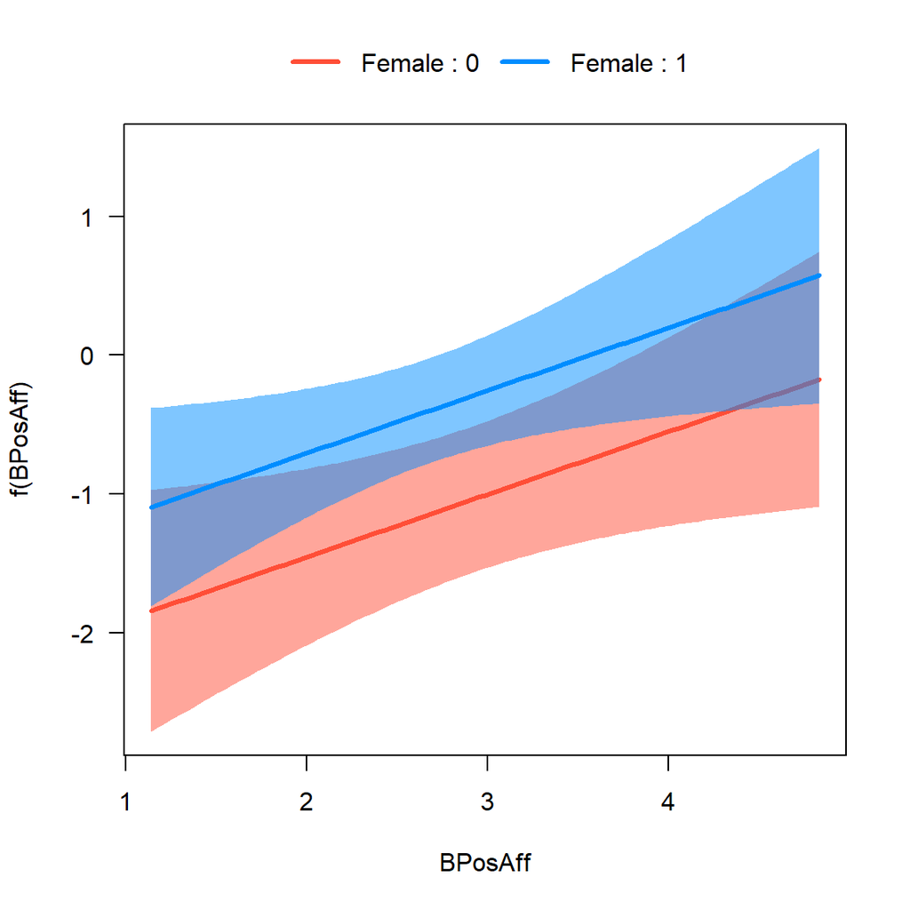

```r
visreg( m3,
 xvar = "BPosAff",
 by = "Female",
 partial = FALSE, rug = FALSE,
 overlay=TRUE)
```

By default, the graphs from `visreg()` are on the logit (log odds) scale. This shows clearly how we are still dealing with a (generalized) linear model. However, this is a very difficult scale to interpret. To make graphs easier to interpret and present, it is useful to present them on the probability scale. Although it is tedious to calculate probabilities by hand, it is straight forward with `visreg()` by specifying an additional argument, `scale = "response"` to indicate that we want the results on the response scale rather than the link scale.

One thing you will notice about this graph, albeit slight, is that the difference in probabilities is not strictly linear, nor is the difference between women and men the same distance at all levels of average positive affect on the probability scale. Although logistic models are still linear on the link scale, on the response (probability) scale, they are not strictly linear.

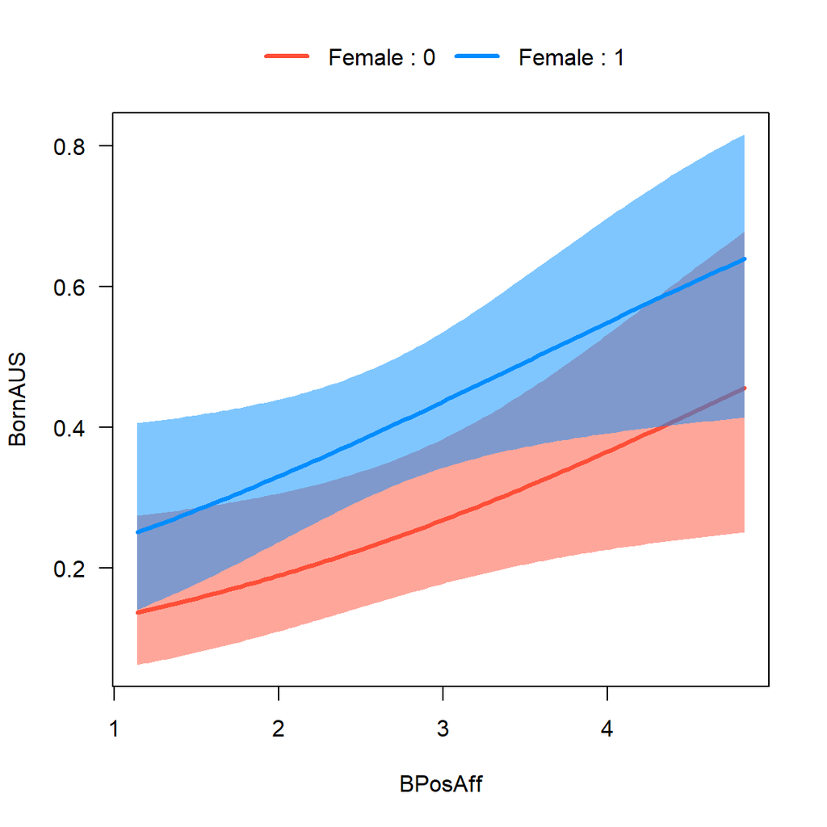

```r
visreg( m3,
 xvar = "BPosAff",
 by = "Female",
 partial = FALSE, rug = FALSE,
 overlay=TRUE,
 scale = "response")
```

# Generalized Linear Mixed Models

Generalized Linear Mixed Models (GLMMs) are just like regular linear mixed models (LMMs) except that insetad of the outcome variable being a continuous, normally distributed variable, we assume the outcome is a binary variable (0/1) and follows a Bernoulli distribution and we use the logit link function to map the outcome to our predictors on a linear scale.

Otherwise, GLMMs and LMMs are basically the same. On the logit (link) scale, we still assume a linear association of predictors and the outcome. We still assume that the random effects follow a (multivariate) normal distribution *on the link scale*.

For GLMMs, we cannot even approximate the degrees of freedom for the model. Because of this, the standard approach is to simply assume that the sample size is large enough that the t distribution approximates a normal distribution. In GLMMs, p-values are based off of assuming that: z = estimate / SE and then looking up p-values based on the Z values. Finally, the Bernoulli / Binomial distribution does not have a meaningful variance estimate so there is no residual variance estimate. Consequently, things like the ICC are not readily calculated (although if critical to your research, approximations do exist).

One other note is that although LMMs can have some convergence issues, estimating GLMMs is even harder for the computer. They typically are slower to estimate and are more prone to convergence issues.

## GLMMs in `R`

GLMMs, specifically logistic mixed models are applicable any time you have a repeatedly measured (or multilevel, such as children within families) data where the outcome is binary.

In the daily diary study data we have used, we do not have a perfect repeatedly measured, binary outcome, so we will make one by defining positive affect scores above 3 (the scale midpoint) as “happy” (scored 1) and otherwise as “unhappy” (scored 0).

```r
## create a binary positive affect variable
## caled PosAffBin, defined as integer values for PosAff > 3
## where 1 = TRUE (PosAff > 3) and 0 = FALSE (PosAff <= 3)
d[, PosAffBin := as.integer(PosAff > 3)]
```

We fit GLMMs by adding a “g” to `lmer()` using the: `glmer()` function. `glmer()` works almost identically to `lmer()`, except that you also must specify the family, which is the assumed distribution for the outcome. We use `binomial()`.

```r
glmm1 <- glmer(PosAffBin ~ 1 + (1 | UserID),
               family = binomial(),
               data = d)

summary(glmm1)
```

```
## Generalized linear mixed model fit by maximum likelihood (Laplace
##   Approximation) [glmerMod]
##  Family: binomial  ( logit )
## Formula: PosAffBin ~ 1 + (1 | UserID)
##    Data: d
##
##      AIC      BIC   logLik deviance df.resid
##     6313     6327    -3154     6309     6397
##
## Scaled residuals:
##    Min     1Q Median     3Q    Max
## -4.193 -0.516 -0.217  0.575  4.889
##
## Random effects:
##  Groups Name        Variance Std.Dev.
##  UserID (Intercept) 4.05     2.01
## Number of obs: 6399, groups:  UserID, 191
##
## Fixed effects:
##             Estimate Std. Error z value Pr(>|z|)
## (Intercept)   -0.716      0.152   -4.72  2.3e-06 ***
## ---
## Signif. codes:  0 '***' 0.001 '**' 0.01 '*' 0.05 '.' 0.1 ' ' 1
```

The output is fairly similar to output for LMMs.

- `R` first tells us how it fit the model (maximum likelihood based on the Laplace approximation).
- Then it tells us the family and link function, logit.
- Then it tells us the formula for the model and the dataset.
- Information criterion (AIC, BIC), the log likelihood, deviance (-2 * log likelihood) and the residual degrees of freedom, which are used for the AIC and BIC.
- Scaled residuals are a sort of normalized residual on the logit scale.
- Random effects are presented on the link (logit) scale and on this scale are assumed to follow a normal distribution. Note that there is no estimated residual variance, due to the outcome being assumed to follow a Bernoulli / Binomial distribution.
- The number of observations and groups (here people) are reported.
- The fixed effects section is familiar with estimates (coefficients), standard errors (Std. Error), z values in place of t values, and p-values based off the z values, Pr(>|z|).

Below we visualise the BLUPs for the random intercept on the logit (link) scale and the probability (response) scale. Note that the first is assumed to be normally distributed (appears somewhat violated in this instance). The second does not need to follow (and will not) a normal distribution. The second distribution on the probability scale shows the average probability that each participant is “happy” (PosAff > 3) at any given survey.

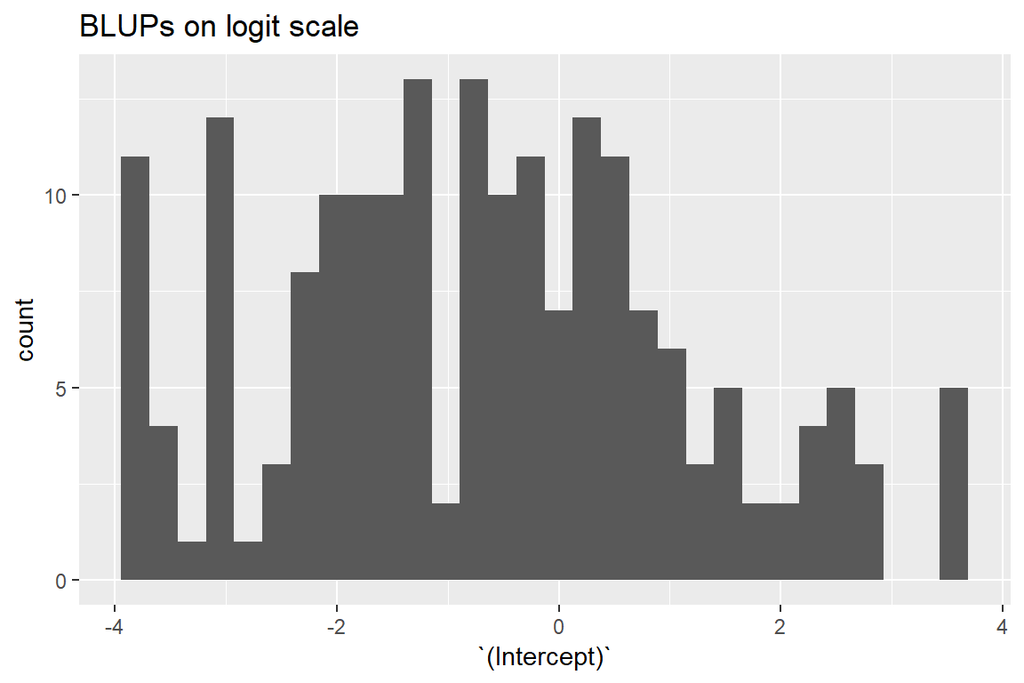

```r
ggplot(coef(glmm1)$UserID, aes(`(Intercept)`)) +
  geom_histogram() +
  ggtitle("BLUPs on logit scale")
```

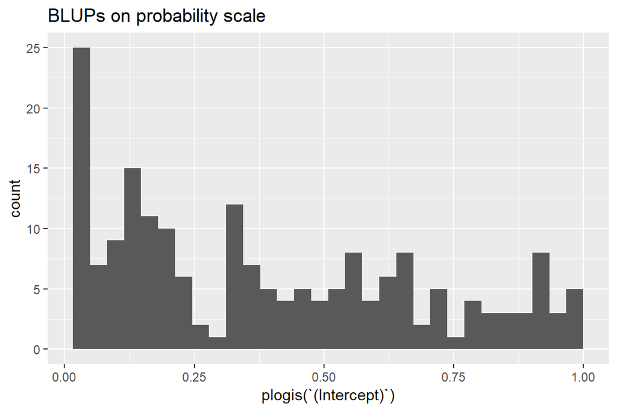

```r
ggplot(coef(glmm1)$UserID, aes(plogis(`(Intercept)`))) +
  geom_histogram()+
  ggtitle("BLUPs on probability scale")
```

We can easily convert the fixed effect intercept estimate to a probability for interpretation using the `plogis()` function in `R`. However, GLMMs have a complexity. Because the logit function is not linear, when you transform from the link scale to the probability scale changes the results. For example, the average of the individual estimates on the link scale converted to probabilities, is not the same as the average of the indivdiual estimates on the probability scale. To see this, we calculate the BLUPs for the random effect intercept. In one case, we take the average then back transform to probabilities using the `plogis()` function. In the second example, we back transform then average. The results are rather different. **If you want the average probability, the second approach is the correct one.**

```r
## random intercept BLUPs
blups <- coef(glmm1)$UserID[["(Intercept)"]]

## back transform average of the BLUPs
plogis(mean(blups))
```

```
## [1] 0.34
```

```r
## average back transformed BLUPs
## this is the correct way to estimate the average
## probability of being happy
mean(plogis(blups))
```

```
## [1] 0.39
```

An implication of this difference is that although you can easily generate predicted plots for the fixed effects of GLMMs, these are only valid on the link scale.

As with regular LMMs, we can add predictors and include them as fixed and random effects, if desired. This next model tests stress as a fixed and random effects predictor of binary positive affect. Note this takes a few seconds to run.

```r
glmm2 <- glmer(PosAffBin ~ 1 + STRESS + (1 + STRESS | UserID),
               family = binomial(),
               data = d)

summary(glmm2)
```

```
## Generalized linear mixed model fit by maximum likelihood (Laplace
##   Approximation) [glmerMod]
##  Family: binomial  ( logit )
## Formula: PosAffBin ~ 1 + STRESS + (1 + STRESS | UserID)
##    Data: d
##
##      AIC      BIC   logLik deviance df.resid
##     5619     5653    -2804     5609     6394
##
## Scaled residuals:
##    Min     1Q Median     3Q    Max
## -4.711 -0.464 -0.161  0.432 10.832
##
## Random effects:
##  Groups Name        Variance Std.Dev. Corr
##  UserID (Intercept) 4.7468   2.179
##         STRESS      0.0602   0.245    -0.39
## Number of obs: 6399, groups:  UserID, 191
##
## Fixed effects:
##             Estimate Std. Error z value Pr(>|z|)
## (Intercept)   0.3080     0.1714     1.8    0.072 .
## STRESS       -0.5082     0.0336   -15.1   <2e-16 ***
## ---
## Signif. codes:  0 '***' 0.001 '**' 0.01 '*' 0.05 '.' 0.1 ' ' 1
##
## Correlation of Fixed Effects:
##        (Intr)
## STRESS -0.394
```

In the results, we can see the usual information. All of these results can be interpretted basically the same as for LMMs *on the link scale*. For example, we can interpret that when stress is 0, the average log odds of being happy is 0.31 and that about two thirds of people have a log odds of being happy between -1.87 and 2.49, found by taking the fixed effect intercept estimate plus or minus the random effect intercept standard deviation estimate.

We can interpret the slope for stress as indicating that on average, a one unit increase in stress is associated with a -0.51 change in the log odds of being happy. We also can exponentiate the estimate and say that the fixed effects revealed that each unit change in stress was associated with 0.6 times the odds of being happy.

Here the odds ratio is calculated by taking: $e^b$ or in `R` `exp(fixef(glmm2))`

Plotting or visualization on the log odds scale for the fixed effects also is easy.

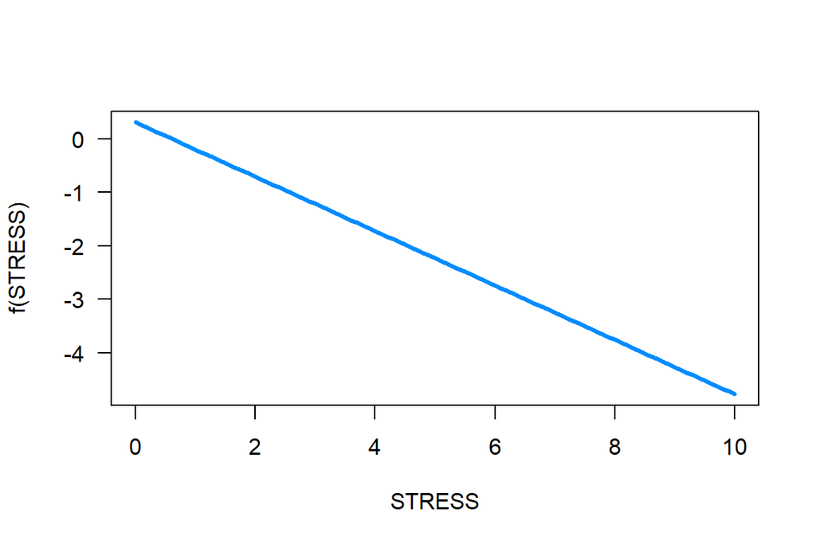

```r
visreg(glmm2,
       xvar = "STRESS",
       partial=FALSE, rug=FALSE)
```

However, although it is equally easy to produce a plot on the probability scale, these probabilities based solely on the fixed effects do not have any easy interpretation. Specifially, the probabilities from the fixed effects only are not the average probability of being happy as a function of stress.

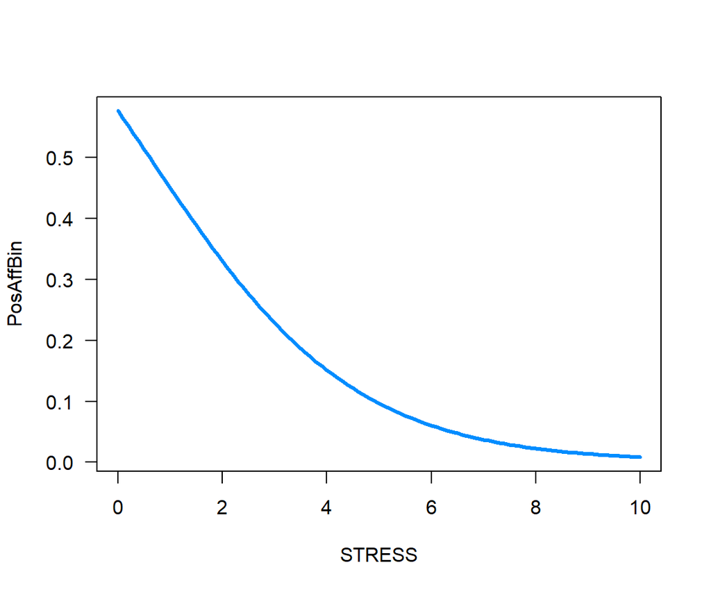

```r
visreg(glmm2,
       xvar = "STRESS",
       partial=FALSE, rug=FALSE,
       scale = "response")
```

To get the actual average probability of being happy given stress, we have to get predicted probabilities for each person in the dataset, and average the results. In the resulting figure, the predicted average probability never gets as low as when simply backtransforming the predicted log odds based on only fixed effects. This highlights how these two appraoches are not equivalent.

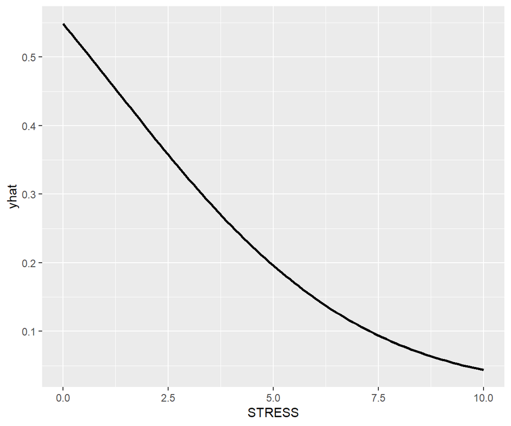

```r
## data for predictions, must set both stress and UserID
predictdata <- as.data.table(expand.grid(
  STRESS = seq(0, 10, by = .1),
  UserID = unique(d$UserID)))

## generate predicted probabilities
## type = "response" indicates predictions on the response
## (i.e., probability) scale
predictdata$yhat <- predict(glmm2, newdata = predictdata,
                            type = "response",
                            re.form = NULL)

## calculate the average probability across participants
## by stress level
predictdataavg <- predictdata[, .(yhat = mean(yhat)), by = STRESS]

ggplot(predictdataavg, aes(STRESS, yhat)) +
  geom_line(size = 1)
```

One benefit of generating individual predictions is that we can plot the individual predicted probabilities to get a sense of the differences due to random effects. First, we do it on the logit scale, then on the probability scale.

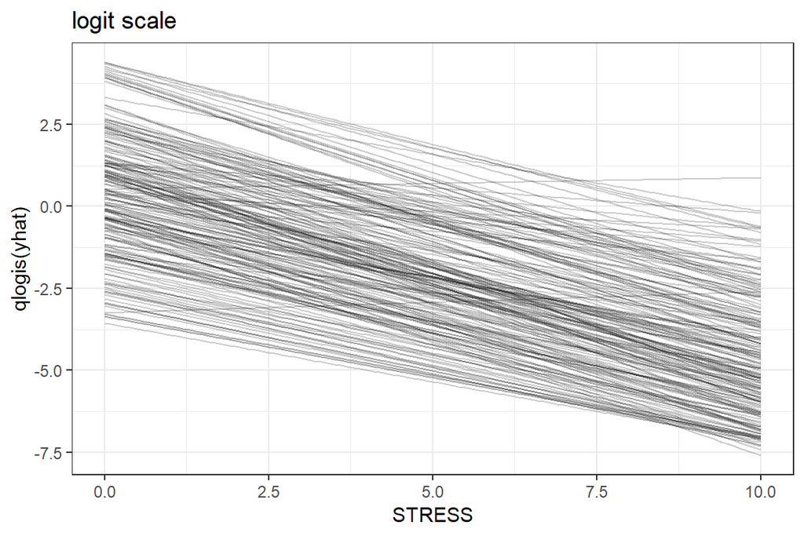

```r
## plot the indivdiual curves
ggplot(predictdata, aes(STRESS, qlogis(yhat), group = UserID)) +
  geom_line(alpha = .2) +
  theme_bw() + ggtitle("logit scale")
```

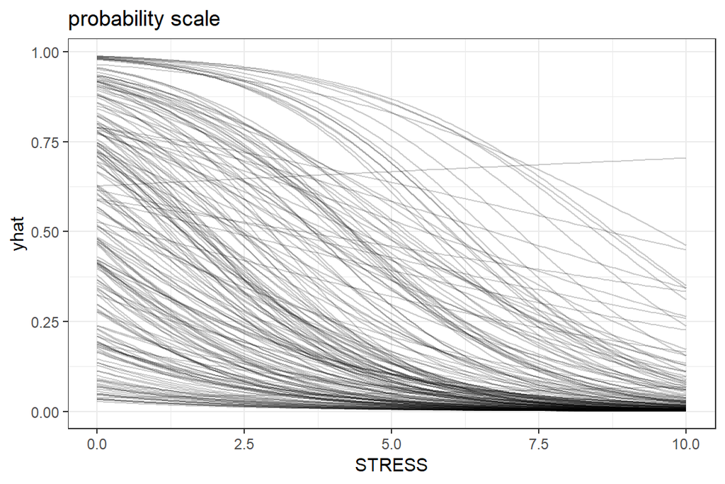

```r
ggplot(predictdata, aes(STRESS, yhat, group = UserID)) +
  geom_line(alpha = .2) +
  theme_bw() + ggtitle("probability scale")
```